# New blog about finance and R

Marcelo Perlin

2017-01-02

## About me

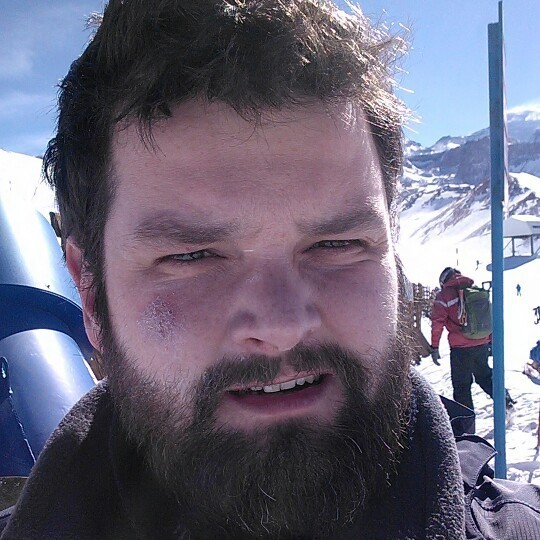

Hello everyone! This is the first (ever) post for a new blog about Finance and R. My name is Marcelo Perlin and my day job is assistant professor of Finance in Federal University of Rio Grande do Sul, in the city of south of Brazil (Porto Alegre). I received my PhD in Finance from Reading University (ICMA Centre) in 2010 and I have a long experience in doing applied research in Finance. You can find more details about my work in my [personal homepage](https://sites.google.com/site/marceloperlin/).

In the computational side, I fell in love with R the moment I learned to use it. I have a long standing working relationship with Matlab and I was impressed in observing how much easier it was to manipulate and process data with R, once you understand its sintax. I translated all of my finance libraries from Matlab to R, realizing during the process that I was writing R code much faster and mantainable than I would do in Matlab. After that, I was hooked. I’m currently writing a book about R and Finance that I hope to publish soon. The portuguese version should be up in amazon very soon.

In this blog I will write about my CRAN packages and any other ideas about finance and R or research papers that I’m currently working on. The content will be mostly about ways to make the life of a financial data analyst more enjoyable.

Oh, and I’m not researching and teaching, I also love playing tennis and swimming. Fell free to drop me an email at marceloperlin@gmail.com.

Best,

Marcelo.